# Interpersonal synchrony increases prosocial behavior in infants - Cirelli - 2014 - Developmental Science - Wiley Online Library

[Developmental Science](https://onlinelibrary.wiley.com/journal/14677687)

[Volume 17, Issue 6](https://onlinelibrary.wiley.com/toc/14677687/2014/17/6) p. 1003-1011

Short Paper

Full Access

# Interpersonal synchrony increases prosocial behavior in infants

[Laura K. Cirelli](https://onlinelibrary.wiley.com/action/doSearch?ContribAuthorRaw=Cirelli%2C+Laura+K),

[Kathleen M. Einarson](https://onlinelibrary.wiley.com/action/doSearch?ContribAuthorRaw=Einarson%2C+Kathleen+M),

[Laurel J. Trainor](https://onlinelibrary.wiley.com/action/doSearch?ContribAuthorRaw=Trainor%2C+Laurel+J),

Address for correspondence: Laurel J. Trainor, Department of Psychology, Neuroscience & Behaviour, McMaster University, Hamilton, ON L8S 4K1, Canada; e-mail:

First published: 12 June 2014

https://doi.org/10.1111/desc.12193

Citations: 254

## Abstract

Adults who move together to a shared musical beat synchronously as opposed to asynchronously are subsequently more likely to display prosocial behaviors toward each other. The development of musical behaviors during infancy has been described previously, but the social implications of such behaviors in infancy have been little studied. In Experiment 1, each of 48 14-month-old infants was held by an assistant and gently bounced to music while facing the experimenter, who bounced either in-synchrony or out-of-synchrony with the way the infant was bounced. The infants were then placed in a situation in which they had the opportunity to help the experimenter by handing objects to her that she had ‘accidently’ dropped. We found that 14-month-old infants were more likely to engage in altruistic behavior and help the experimenter after having been bounced to music in synchrony with her, compared to infants who were bounced to music asynchronously with her. The results of Experiment 2, using anti-phase bouncing, suggest that this is due to the contingency of the synchronous movements as opposed to movement symmetry. These findings support the hypothesis that interpersonal motor synchrony might be one key component of musical engagement that encourages social bonds among group members, and suggest that this motor synchrony to music may promote the very early development of altruistic behavior.

A video abstract of this article can be viewed at http://www.youtube.com/watch?v=IaqWehfDm7c&feature=youtu.be

## Research highlights

- Moving to music in synchrony with an adult increases 14-month-old infants' helpfulness
- Prosocial effects of interpersonal movement develop early
- Congruent movement synchrony has the same prosocial effect as mirrored synchrony

## Introduction

Music is present at social events such as religious ceremonies, military activities, and celebrations where within-group social affiliation, emotional bonding, and sharing common goals are desirable (Dissanayake, 2006). The steady underlying beat that can be extracted from music encourages entrained motor movements (Fujioka, Trainor, Large & Ross, 2012; Large, 2000), and recent studies suggest that adults who engage in a task that encourages high levels of interpersonal motor synchrony later display heightened affiliative behaviors toward one another. For example, synchronized walking, singing, and finger tapping lead to increased cooperative behaviors and higher ratings of likeability among those involved (Anshel & Kippler, 1988; Hove & Risen, 2009; Launay, Dean & Bailes, 2013; Valdesolo, Ouyang & DeSteno, 2010; Wiltermuth & Heath, 2009). This effect of interpersonal synchrony on prosocial behaviors that influence social cohesion may result from perceptual and attentional biases toward synchronous counterparts (Macrae, Duffy, Miles & Lawrence, 2008; Woolhouse & Tidhar, 2010), or from appraisals of self-similarity among synchronous group members (Valdesolo & DeSteno, 2011). One study suggests that music also influences social behavior during childhood. Children who participated in a musical game later played together in a more helpful and cooperative manner than children who participated in a non-musical game (Kirschner & Tomasello, 2010), although the specific role of interpersonal synchrony was not measured in this study. Here we test whether interpersonal synchrony promotes prosocial behavior in infancy.

Some aspects of sophisticated musical processing develop early. Young infants prefer musically consonant over dissonant sounds (Trainor, Tsang & Cheung, 2002), they can remember and detect changes in melodies (Plantinga & Trainor, 2009), rhythms (Chang & Trehub, 1977), and timbres (Trainor, Lee & Bosnyak, 2011), and by 1 year of age, they show evidence of enculturation to the timing structures and pitch classes used in the music of their culture (Gerry, Unrau & Trainor, 2012; Hannon & Trehub, 2005; Trainor & Trehub, 1992). Furthermore, early musical processing is influenced by interactions between auditory and motor systems. Infants bounced to an ambiguous rhythm pattern on either every second or every third beat subsequently preferred to listen to the version of that pattern with accented beats matching the pattern to which they had been bounced (Phillips-Silver & Trainor, 2005). Infants who took part in active participatory parent-and-infant music classes showed enhanced musical processing, heightened brain responses to sound, and increased use of prelinguistic gestures after participation, in comparison to infants who were assigned randomly to classes where music was experienced passively in the background (Gerry *et al*., 2012; Trainor, Marie, Gerry, Whiskin & Unrau, 2012). Most relevantly, infants in the active participatory music-making group also showed more positive social-emotional development.

By their first birthday, infants are also becoming active social agents, who understand that the behavior of others can be goal-directed (see Sommerville & Woodward, 2010, for a review). They are beginning to engage in coordinated activities that require joint attention with another individual (see Moore & Dunham, 1995; Tomasello, Carpenter, Call, Behne & Moll, 2005, for reviews). For example, 12-month-old infants will point to an object in order to inform another person of its whereabouts (Liszkowski, Carpenter, Striano & Tomasello, 2006; Liszkowski, Carpenter & Tomasello, 2008). Altruistic behavior is also emerging at this age; 14-month-olds are motivated to help an experimenter by returning objects that have been dropped (Warneken & Tomasello, 2006, 2007). Young infants quickly form preferences for social agents that help others (Hamlin, Wynn & Bloom, 2007; Hamlin & Wynn, 2012) and visual cues such as attractiveness, gender, and self-similarity influence their social preferences (Kelly, Liu, Ge, Quinn, Slater, Lee, Liu & Pascalis, 2007; Kinzler, Dupoux & Spelke, 2007; Langlois & Roggman, 1987; Quinn, Yahr, Kuhn, Slater & Pascalis, 2002). Twenty-one-month-olds even direct their instrumental helping behaviors toward adults who previously attempted to provide a toy, regardless of whether the adult succeeded (Dunfield & Kuhlmeier, 2010). Although these children were somewhat older than the infants in the present investigation, these findings suggest that social interactions can later influence infant instrumental helpfulness.

The goal of the present investigation was to determine whether 14-month-old infants use interpersonal motor synchrony in the context of musical engagement as a cue to direct their own prosocial behaviors. If infants are similar to adults, moving to music in synchrony with an adult should encourage infants to feel similar to and/or attentive toward this adult (Macrae *et al*., 2008; Valdesolo & DeSteno, 2011). This should increase later prosociality directed toward this adult. On the other hand, bouncing asynchronously with an adult should not increase prosociality. We therefore hypothesized that infants would be more likely to display helping behaviors toward an experimenter following an experience of interpersonal synchrony as opposed to interpersonal asynchrony.

We also investigated whether the predictability of the musical movement was important. Typically, musical engagement involves temporal alignment of movements to evenly spaced, predictable beats. Like interpersonal synchrony, being able to predict another person's movements could make person-perception easier, which could then influence later social behavior. In all previous research on the influence of interpersonal musical engagement on social behavior, synchrony and predictability have either been confounded (Kirschner & Tomasello, 2010), or predictability has been held constant across synchronous and asynchronous conditions (e.g., Hove & Risen, 2009; Valdesolo *et al*., 2010; Wiltermuth & Heath, 2009). To investigate the influence of movement predictability on prosociality, we compared the helping rates of infants bounced to music with evenly spaced (isochronous) and therefore predictable beats to the helping rates of infants bounced to music with unevenly spaced, unpredictable beats.

To investigate these questions, the assistant held and bounced each infant to music while facing the experimenter (see Figure 1 and Movie S1). The infant watched the experimenter, who bounced either in-synchrony or out-of-synchrony with the way the infant was being bounced. To examine the role of movement predictability, the assistant and experimenter either bounced to an evenly spaced, predictable beat while the infant listened to the original version of the song, or they bounced to an unevenly spaced, unpredictable beat while the infant listened to a version of the song distorted in time such that beat-to-beat onsets varied randomly. After this, we tested the infants' willingness to help the experimenter with whom they had previously bounced. Specifically, we measured whether infants would hand back objects to the experimenter that she had ‘accidentally’ dropped, following the work of Warneken and Tomasello (2007), which shows that 14-month-olds understand the experimenter's intentions, and will sometimes display such spontaneous instrumental helping behaviors.

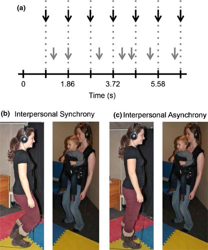

**Figure 1**

Between-subject conditions during the Interpersonal Movement Phase. (a) A visual representation of how infants were bounced over time. Arrows represent the downbeat, or the lowest point of the assistant's and the experimenter's bounce. In the evenly spaced beats conditions (shown in black), downbeats were isochronous and predictable. In the unevenly spaced beats conditions (shown in gray), the spacing between downbeats varied randomly among 11 preset inter-downbeat-intervals. The assistant and experimenter either bounced (b) synchronously or (c) asynchronously. In the evenly spaced beats + asynchrony condition, the experimenter bounced 33% faster or slower than the assistant holding the infant. In the unevenly spaced beats + asynchrony condition, the assistant and experimenter each bounced to a differentially randomized version of the 11 inter-downbeat time intervals.

## Experiment 1

### Participants

Infants were recruited from the Developmental Studies Database at McMaster University. Forty-eight walking infants from English-speaking homes (24 girls; *M* age = 14.2 months; *SD* = 0.2 months) completed the experiment. An additional 14 infants were excluded because of excessive fussiness (*n* = 10) or equipment failure (*n* = 4). The McMaster Research Ethics Board (MREB) approved all experimental procedures. Informed consent was obtained from all parents.

### Phase 1: Interpersonal Movement Phase

#### Stimuli

Infants heard a 145 s Musical Instrument Digital Interface (MIDI) version of ‘Twist and Shout’ (by The Beatles) played over loudspeakers. Infants in the ‘evenly spaced (predictable) beats’ conditions heard the original version of this track (beats per minute (BPM) = 129; Audio S1). Infants in the ‘unevenly spaced (unpredictable) beats’ conditions heard the modified version of this track, in which the inter-beat intervals changed after each successive beat (Audio S2; SI has stimuli creation details). In this case, because the time interval between beats varied randomly, it was not possible to predict the time of the next beat. The tracks were MIDI generated, so there was no acoustic distortion associated with the tempo changes.

While the infant listened to one of the two versions of ‘Twist and Shout’, the assistant and experimenter listened to wood block beats on ‘bounce instruction tracks’ via headphones. These beats were either synchronous or asynchronous with the version of ‘Twist and Shout’ to which the infant was bounced. Thus there were four bounce conditions: synchronous bouncing/evenly spaced beats; synchronous bouncing/unevenly spaced beats; asynchronous bouncing/evenly spaced beats; asynchronous bouncing/unevenly spaced beats. The assistant and experimenter were instructed to bounce by bending at the knees, so that the lowest point of their bounce aligned temporally with the woodblock sounds. See SI for details on beat track creation, and for analyses that verified that the assistant and experimenter bounced at the appropriate times.

#### Procedure

Upon arrival, the assistant interacted with the infant while the experimenter explained the procedure to the parent(s). Parents completed three subtests (‘Smiling’, ‘Approach’, and ‘Activity’) of the Infant Behavior Questionnaire (IBQ) (Rothbart, 1981) in order to account for pre-existing individual differences in infants' sociability and willingness to approach novel objects. The experimenter then left the room while the assistant exposed the infant to the objects that would later be used in the helping tasks. The assistant identified each item (paper ball, clothespin, marker) by name, and offered the items to the infant. Once the infant touched each of the three objects, the Interpersonal Movement Phase began.

The experimenter stood 4.5 feet in front of the assistant and the infant, directly facing the pair. The bounce procedure was initiated via a button press by the experimenter. This simultaneously triggered the onset of the melodic stimuli heard through speakers by the infant and the ‘bounce instruction tracks’ heard through headphones by the assistant and experimenter (see SI for Apparatus details). The assistant and experimenter bounced for 145 s according to the bounce instructions while the infant listened to the melodic stimuli (see video S1 for an example). The assistant and experimenter wore Nintendo Wii remotes at their waists, so that their vertical acceleration over time could be recorded and compared among the four interpersonal movement conditions to ensure appropriate and consistent bounce quality across conditions (see SI for results).

### Phase 2: Prosocial Test Phase

#### Procedure

The infant was placed on a foam mat on the floor of the sound-attenuating chamber. The assistant left the room, and the experimenter began the helping tasks. The order of the three helping tasks was counterbalanced across conditions and between genders.

The present study included three trials each of three instrumental helping tasks based on those developed by Warneken and Tomasello (2007): the paper ball task (experimenter tries to pick up out-of-reach paper balls with tongs and place them into a bucket), the marker task (experimenter draws a picture with markers and ‘accidently’ bumps the markers off the table), and the clothespin task (experimenter clips dishcloths up on a clothesline and ‘accidently’ drops the clothespins she is using).

For all tasks and trials, the experimenter captured the infant's attention before dropping the target object. Each of the three trials began when the experimenter reached for the target object. For the first 10 s, the experimenter focused her gaze on the desired object. For the next 10 s, she alternated her gaze between the object and the infant. For the final 10 s, she vocalized repeatedly about the object (‘my paper ball!’, ‘my marker!’, or ‘my clothespin!’). The trial ended either when the infant gave the dropped object to the experimenter or after 30 s. Parents were asked to remain passive and to refrain from communicating with their infant (see SI for task details; S2 for example videos).

#### Data coding

To calculate overall rate of helpfulness, these tasks were videotaped and later coded by two raters blind to the conditions. During each of the nine trials, video raters assigned one point if the infant handed the desired object to the experimenter within the 30-s trial window. If the infant attempted unsuccessfully to hand back the object, or handed it back once the 30-s trial window had elapsed, the infant was assigned 0.5 points. The mean helping rate across tasks was calculated, and used as each infant's overall rate of helpfulness. Inter-rater reliability for video coding was high, *r* = 0.98. Raters also recorded elapsed time before helping occurred, to calculate scores for spontaneous helping (0–10 s into trial, while experimenter focuses only on the object) and two measures of delayed helping (11–20 s into trial, while experimenter alternates gaze between object and infant; 21–30 s into trial, while experimenter names desired object).

### Results

We analyzed the correlation between helping rates and parent-rated IBQ scores on ‘smiling’, ‘approach’, and ‘activity’. When these measures correlated with the dependent variable in question, they were included as covariates in an ANCOVA analysis. Otherwise, a standard ANOVA is reported.

#### Overall helping

An ANOVA on overall helpfulness rate (Figure 2), with independent variables synchrony (bouncing in-synchrony; bouncing out-of-synchrony) and beat predictability (evenly spaced and predictable; unevenly spaced and unpredictable), revealed a trend for infants to be more helpful following interpersonal synchrony (50.6%, SEM = 6.1%) compared to asynchrony (34.0%, SEM = 6.6%), *F*<sub>(1,44)</sub> = 3.45, *p* = .07, *η*<sub>*p*</sub><sup>2</sup> = 0.07. The main effect of beat predictability, *F*<sub>(1,44)</sub> = 2.56, *p* = .12, and the interaction between synchrony and beat predictability were not significant, *F*<sub>(1,44)</sub> = 0.11, *p* = .75.1

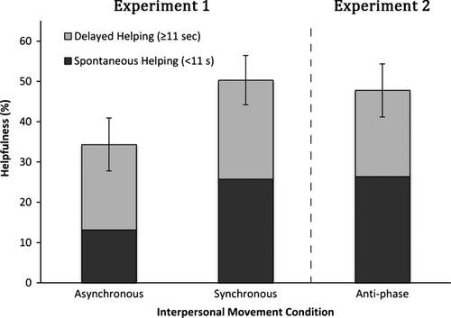

**Figure 2**

#### Spontaneous and delayed helping

A similar ANOVA on spontaneous helpfulness (within 0–10 s) revealed that infants were significantly more likely to demonstrate spontaneous helping following interpersonal synchrony (25.8%, SEM = 4.3%) compared to interpersonal asynchrony (13.1%, SEM = 3.9%), *F*<sub>(1,44)</sub> = 4.75, *p* < .05, *η*<sub>*p*</sub><sup>2</sup> = 0.10. Neither the main effect of beat predictability (*F*<sub>(1,44)</sub> = 1.31, *p* = .26) nor the interaction between synchrony and beat predictability (*F*<sub>(1,44)</sub> = 0.73, *p* = .40) was significant.

The two measures of delayed helping (10–20 s; 20–30 s post-trial onset) did not differ statistically and so their values were combined into one measure for delayed helping (>11 s into the trial). Delayed helpfulness rates (>10 s) correlated significantly with the IBQ scale of ‘approach’, *r* = −0.39, *p* < .01. Infants who were rated as less likely to shy from novelty were more likely to display delayed helpfulness. An ANCOVA controlling for the variability explained by ‘approach’ scores was conducted on delayed helpfulness. The main effects of interpersonal synchrony (*F*<sub>(1,44)</sub> = 0.35, *p* = .56), beat predictability (*F*<sub>(1,44)</sub> = 1.54, *p* = .22), and their interaction (*F*<sub>(1,44)</sub> = 0.17, *p* = .68) were not significant.

These results suggest that synchrony specifically encourages spontaneous helping, but not delayed helping. Spontaneous helping occurs quickly and before the experimenter directs her attention toward the infant, which may reflect an early form of altruism. Delayed helping occurs after the experimenter involves the infant through her gaze direction and vocalizations, and therefore may reflect compliance rather than altruism. The correlational results further suggest that spontaneous and delayed helping are dissociable, and that only delayed helping is related to personality traits.

#### Post-hoc video rating results

To verify that the experimenter acted consistently across conditions during both phases of the experiment, two video discrimination tasks were performed (see SI for details). In the first task, 16 naïve adults watched paired videos of the experimenter's face and torso during the Interpersonal Movement Phase. A one-sample *t*-test revealed that raters' ability to distinguish whether the experimenter was in a synchronous or an asynchronous bouncing condition was not significant, *t*<sub>(15)</sub> = 1.11, *p* = .28. A paired-samples *t*-test revealed that raters did not rate the level of happiness displayed by the experimenter differently in the synchronous versus asynchronous conditions, *t*<sub>(15)</sub> = 0.90, *p* = .38. In addition, the average happiness ratings for each video did not correlate significantly with the helpfulness scores of the infants from that session, *R* = 0.10, *p* = .57.

In the second post-hoc video discrimination task, a separate group of 16 naïve adults watched paired videos showing experimenter behavior during the Prosocial Test Phase (see SI for details). One-sample *t*-tests revealed that raters did not significantly distinguish the experimenter's interactions with infants from the synchronous/evenly spaced beat condition from her interactions with infants from the asynchronous/unevenly spaced beat condition. This was true both when the infant did or did not help the experimenter (*t*<sub>(15)</sub> = 0.52, *p* = .61; *t*<sub>(15)</sub> = 1.07, *p* = .30). The results of these two video rating tasks indicate that differences in infants' helping behaviors cannot be attributed to noticeable experimenter bias during either phase of the experiment.

## Experiment 2

### Participants

Twenty walking infants from English-speaking homes participated (10 girls; *M* age = 14.4 months; *SD* = 0.5 months). An additional three infants were excluded due to excessive fussiness.

### Procedure

The procedure was identical to the procedure for the synchronous/evenly spaced condition of Experiment 1 with the following exception: although the assistant still bounced the infant so that the low part of her bounce aligned with the woodblock sounds on the downbeats, the experimenter instead bounced so that the high part of her bounce (with legs fully extended) aligned with the woodblock sounds on the downbeats. This resulted in alternating bounces; when the assistant and infant were at the top of their bounce the experimenter was at the bottom, and vice versa.

### Results

There was a trend for a positive correlation between helpfulness and IBQ-rated ‘smiling’, *r* = 0.41, *p* = .07, and a significant correlation between helpfulness and ‘approach’, such that infants less likely to shy from novelty were more likely to help, *r* = −0.50, *p* < .05.

#### Overall helping

The helping rates of the infants in the anti-phase bouncing condition were compared to the helping rates of infants in the ‘synchronous’ and the ‘asynchronous’ conditions from Experiment 1, using two a priori planned comparisons. Two GLM ANCOVAs with ‘smiling’ and ‘approach’ as covariates revealed that, while the overall helping rates of infants in the anti-phase condition (*M* = 47.8%, SEM = 6.6%) were not significantly different from the helping rates of the infants in synchronous condition, *F*<sub>(1, 40)</sub> = 0.14, *p* = .71, infants in the anti-phase condition were significantly more likely to display helpfulness than infants in the asynchronous condition, *F*<sub>(1, 40)</sub> = 4.50, *p* < .05, *η*<sub>*p*</sub><sup>2</sup> = .10 (see Figure 2). This indicates that, like synchronous bouncing, anti-phase bouncing leads to a boost in the prosocial behavior of 14-month-olds.

#### Spontaneous and delayed helping

We repeated the analyses above for spontaneous helpfulness (0–10 s) and found that helping rates in the anti-phase condition did not differ from helping rates in synchronous condition of Experiment 1, *F*<sub>(1, 40)</sub> = 0.01, *p* = .96, but did differ significantly from helping rates in the asynchronous condition, *F*<sub>(1, 40)</sub> = 4.78, *p* < .05, *η*<sub>*p*</sub><sup>2</sup> = .11. For delayed helping, as expected, there were no significant differences across conditions (*p*s > .5). These results suggest that anti-phase and in-phase synchrony lead to similar increases in spontaneous helping.

## Discussion

Interpersonal motor synchrony may allow involved parties to mark each other as similar to one another (Valdesolo & DeSteno, 2011), which in turn leads to an increase in affiliative behaviors. In infancy, other cues for self-similarity such as race and native language have been shown to contribute to social preference (Kelly *et al*., 2007; Kinzler *et al*., 2007). Interpersonal motor synchrony may work similarly, but has also been hypothesized to enhance person-perception by directing attention to synchronously moving counterparts (Macrae *et al*., 2008). One way to test this hypothesis in future studies would be to measure how much eye contact the infants make with synchronously versus asynchronously moving partners. These results are also consistent with the social cohesion model of musical behavior, which proposes that group musical engagement facilitates cooperation among group members. This heightened cooperation enhances that group's ability to survive both directly and indirectly (Brown, 2000; Freeman, 2000; Roederer, 1984).

The social cohesion model does not specify whether social facilitation is driven by a cue that is restricted to musical behavior, or by a cue that is relevant to, but not restricted to, musical behavior. In the present results, increased helpfulness, a form of prosocial behavior that can enhance group cohesion, was observed regardless of whether interpersonal movements were evenly spaced (and therefore typically musical and highly predictable) or unevenly spaced (and therefore not typically musical and not predictable). Our results are consistent with the idea that social facilitation driven by interpersonal synchrony is not restricted to musical contexts. In fact, it is not clear that music is even necessary as long as movements are synchronous. This is an important question for future research. However, the evenly spaced beats in music provide an especially effective context for encouraging synchronous movement among people. Outside of a laboratory setting, it would be difficult for individuals to coordinate movements occurring at random intervals. As such, musical behaviors are a potentially salient source of interpersonally synchronized movement in everyday life.

Interpersonal synchrony is a common experience in an infant's social world. Caregivers often engage in musical behaviors such as singing, clapping, dancing, and bouncing with their young children. Our results suggest that such activities promote socially cohesive behaviors between infants and caregivers. Moreover, since the helping behaviors manipulated in this experiment represent an early form of altruism (Warneken & Tomasello, 2006), the results presented here suggest that 14-month-old infants are already using social cues to direct their interpersonal helping, and that interpersonal synchrony is one such cue.

## Acknowledgements

This research was funded by a grant from the Natural Sciences and Engineering Research Council of Canada to LJT (197033-2009) and to LKC, and by an Ontario Graduate Scholarship to LKC. LKC was the primary researcher and LJT the senior researcher, but all authors contributed to the ideas, analyses, and writing of the manuscript. LKC and KME tested the participants. We thank Leah Latterner for coding videos, Stephanie Wan for helping with post-hoc video coding data collection, and Dave Thompson for technical assistance. We thank Terri Lewis for comments on an earlier draft.

## Note

1 Due to the non-normality of this sample (Shapiro-Wilk = 0.92, *p* < .05) we repeated the analysis using trimmed means, a more robust measure of central tendency (Brown & Forsythe, 1974; Field, 2009). Infants with the highest and lowest overall helping score from each of the four groups were removed for this analysis. With this adjusted sample, overall helpfulness correlated significantly with parent-rated IBQ scores of ‘approach’ (infants likelihood to shy from novelty), *r* = −0.38, *p* < .05. Using an ANCOVA on the trimmed means, controlling for the effects of ‘approach’, the main effect of synchrony reached significance, *F*<sub>(1,35)</sub> = 5.38, *p* < .05, *η*<sub>*p*</sub><sup>2</sup> = 0.13. There was still no significant main effect of beat predictability, *F*<sub>(1,35)</sub> = 2.25, *p* = .14, and no significant interaction between the two variables, *F*<sub>(1,35)</sub> = 0.20, *p* = .66.